# Practical Machine Learning Project

Claus Bo Hansen

January 7, 2019

# Purpose

The purpose of this analysis is to predict the class of physical activity.

**Background**

Using devices such as Jawbone Up, Nike FuelBand, and Fitbit it is now possible to collect a large amount of data about personal activity relatively inexpensively. These type of devices are part of the quantified self movement – a group of enthusiasts who take measurements about themselves regularly to improve their health, to find patterns in their behavior, or because they are tech geeks. One thing that people regularly do is quantify how much of a particular activity they do, but they rarely quantify how well they do it. In this project, your goal will be to use data from accelerometers on the belt, forearm, arm, and dumbell of 6 participants. They were asked to perform barbell lifts correctly and incorrectly in 5 different ways. More information is available from the website here: http://web.archive.org/web/20161224072740/http:/groupware.les.inf.puc-rio.br/har (see the section on the Weight Lifting Exercise Dataset).

# Load libraries

```r
library(dplyr, warn.conflicts = FALSE)
library(caret)
library(Boruta)
library(factoextra)
```

```r
library(corrplot)
library(doParallel)
library(RWeka)
```

# Get Data

Download data and load into variables.

```r
# Data sources
URLs <- c("https://d396qusza40orc.cloudfront.net/predmachlearn/pml-training.csv",
          "https://d396qusza40orc.cloudfront.net/predmachlearn/pml-testing.csv")


# Download files and read into data frames
for (URL in URLs) {
  filename <- gsub("^([^/]*/)*(.*)", "\\2", URL)
  varname <- gsub("^([^\\.]*).*", "\\1", filename)
#  download.file(url = URL, filename, method = "auto") # can be commented out when files are downloaded
  assign(varname, read.csv(filename))
}
```

# Clean Data

Remove observations and variables not useful for modelling.

```r
train_validate <- `pml-training`

# Rows with new_window set to yes are summaries of repetition,
# and should not be included in training/validation
train_validate <- train_validate %>%
  filter(new_window != "yes")

# Columns to be removed
              # Summary columns
regpats <- c("^(kurtosis|skewness|max_|min_|avg_|stddev_|var_|amplitude_)",
              # Not available in "the wild"
             "^(X|user_name|raw_timestamp_part_[12]|cvtd_timestamp|(new|num)_window)$")

# Remove columns matching patterns in regpats
for (regpat in regpats) {
  train_validate <- train_validate[,!grepl(regpat, names(train_validate))]
}
```

# Split into training and validation data sets

Split observations into train data set for model fitting and validate for benchmarking models.

```r
set.seed(1)

# Create indices for training data, stratify classe
trainIndex <- createDataPartition(train_validate$classe, p=0.8, list = FALSE)

# Split train_validate into data_train and data_validate
data_train <- train_validate[trainIndex,]
data_validate <- train_validate[-trainIndex,]
```

# Feature creation

Create new features/variables, which potentially have better predictive power than the “native” predictors. I will create new variables, which contain the product of gyros, accel and magment in the three axes. Example:

accel_PRODUCT_x = accel_belt_x * accel_arm_x * accel_dumbell_x * accel_forearm_x

```r
# Function to add new features
addfeatures <- function(dataset) {
  metrics <- c("gyros", "accel", "magnet")
  axes <- c("x", "y", "z")
  for (metric in metrics) {
    for (axis in axes) {
      productcolumn <- paste(metric,"_PRODUCT_", axis, sep = "")
      beltcolumn <- paste(metric,"_belt_", axis, sep = "")
      armcolumn <- paste(metric,"_arm_", axis, sep = "")
      dumbbellcolumn <- paste(metric,"_dumbbell_", axis, sep = "")
      forearmcolumn <- paste(metric,"_forearm_", axis, sep = "")
      dataset[,productcolumn] <- as.numeric(dataset[,beltcolumn]) * as.numeric(dataset[,armcolumn]) *
        as.numeric(dataset[,dumbbellcolumn]) * as.numeric(dataset[,forearmcolumn])
    }
  }
  dataset
}

# Add features to data_train and data_validate
data_train <- addfeatures(data_train)
data_validate <- addfeatures(data_validate)
```

# Variable normalization

Normalize (center and scale) variables. Normalization parameters are based on training dataset, same parameters must be used on validation and test data.

```r
# Specify which columns to normalize, in this case all but classe
all_cols <- names(data_train)
normalize_cols <- all_cols[!(all_cols %in% c("classe"))]

# Create normalization object, based on training data
normalize_object <- preProcess(data_train[, normalize_cols], method = c("center", "scale"))

# Normalize training and validation data
data_train[, normalize_cols] <- predict(normalize_object, data_train[, normalize_cols])
data_validate[, normalize_cols] <- predict(normalize_object, data_validate[, normalize_cols])
```

# Select variables with predictive power

Use the Boruta package to identify variables correlated with classe.

```r
# Run Boruta
boruta_train <- Boruta(classe ~ ., data = data_train)

# Print result
print(boruta_train)
```

```
## Boruta performed 13 iterations in 3.156314 mins.
##  61 attributes confirmed important: accel_arm_x, accel_arm_y,
## accel_arm_z, accel_belt_x, accel_belt_y and 56 more;
##  No attributes deemed unimportant.
```

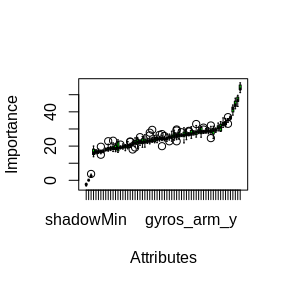

```r
plot(boruta_train)
```

None of the predictors can be eliminated by Boruta.

# Principal Component Analysis (PCA)

Investigate if the number of variables can be reduced to fewer Principal Components while still explaining most of the variance.

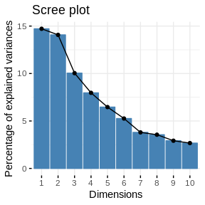

```r
# Use all but classe for PCA
all_cols <- names(data_train)
PCA_input <- all_cols[!(all_cols %in% c("classe"))]

# Extract data frame with only predictors (all for PCA)
predictorvars <- data_train %>%
  select(PCA_input)

# Create PCA object
PCAobject <- prcomp(predictorvars)

# Scree plot
fviz_eig(PCAobject)
```

```r
# Get Eigen values and variance explained
get_eigenvalue(PCAobject)
```

```
##         eigenvalue variance.percent cumulative.variance.percent
## Dim.1  8.977150560     14.716640263                    14.71664
## Dim.2  8.584880106     14.073573943                    28.79021
## Dim.3  6.126396246     10.043272535                    38.83349
## Dim.4  4.859949384      7.967130138                    46.80062
## Dim.5  3.944639233      6.466621693                    53.26724
## Dim.6  3.209036875      5.260716189                    58.52795
## Dim.7  2.317998355      3.799997304                    62.32795
## Dim.8  2.169733213      3.556939694                    65.88489
## Dim.9  1.782041726      2.921379878                    68.80627
## Dim.10 1.629891140      2.671952689                    71.47822
## Dim.11 1.462128693      2.396932284                    73.87516
## Dim.12 1.189320819      1.949706261                    75.82486
## Dim.13 1.090856669      1.788289621                    77.61315
## Dim.14 1.059195861      1.736386658                    79.34954
## Dim.15 0.984549877      1.614016192                    80.96356
## Dim.16 0.931125856      1.526435829                    82.48999
## Dim.17 0.903815253      1.481664349                    83.97166
## Dim.18 0.766375216      1.256352813                    85.22801
## Dim.19 0.729576569      1.196027162                    86.42404
## Dim.20 0.692659922      1.135508069                    87.55954
## Dim.21 0.612338271      1.003833231                    88.56338
## Dim.22 0.581484379      0.953253080                    89.51663
## Dim.23 0.553127125      0.906765779                    90.42340
## Dim.24 0.535665817      0.878140683                    91.30154
## Dim.25 0.491481302      0.805707053                    92.10724
## Dim.26 0.447671791      0.733888183                    92.84113
## Dim.27 0.442706336      0.725748091                    93.56688
## Dim.28 0.381098441      0.624751542                    94.19163
## Dim.29 0.344194718      0.564253636                    94.75588
## Dim.30 0.333791779      0.547199638                    95.30308
## Dim.31 0.306357090      0.502224738                    95.80531
## Dim.32 0.289122129      0.473970703                    96.27928
## Dim.33 0.275450185      0.451557681                    96.73084
## Dim.34 0.220673021      0.361759052                    97.09260
## Dim.35 0.198228980      0.324965542                    97.41756
## Dim.36 0.189609636      0.310835469                    97.72840
## Dim.37 0.166824376      0.273482584                    98.00188
## Dim.38 0.158673147      0.260119913                    98.26200
## Dim.39 0.130609205      0.214113450                    98.47611
## Dim.40 0.116594334      0.191138253                    98.66725
## Dim.41 0.107962991      0.176988509                    98.84424
## Dim.42 0.083201029      0.136395130                    98.98064
## Dim.43 0.079212806      0.129857059                    99.11049
## Dim.44 0.069706164      0.114272400                    99.22476
## Dim.45 0.062491643      0.102445316                    99.32721
## Dim.46 0.054449673      0.089261759                    99.41647
## Dim.47 0.052925761      0.086763542                    99.50324
## Dim.48 0.039452585      0.064676370                    99.56791
## Dim.49 0.035924908      0.058893291                    99.62681
## Dim.50 0.033444935      0.054827762                    99.68163
## Dim.51 0.030795119      0.050483802                    99.73212
## Dim.52 0.029360203      0.048131480                    99.78025
## Dim.53 0.026472604      0.043397711                    99.82365
## Dim.54 0.025658888      0.042063751                    99.86571
## Dim.55 0.021557129      0.035339555                    99.90105
## Dim.56 0.019915620      0.032648557                    99.93370
## Dim.57 0.014832918      0.024316260                    99.95801
## Dim.58 0.011830109      0.019393621                    99.97741
## Dim.59 0.006018865      0.009866991                    99.98727
## Dim.60 0.005672698      0.009299505                    99.99657
## Dim.61 0.002089715      0.003425763                   100.00000
```

95.3% of variance is explained by the first 30 Principal Components, I will use these first 30 PCs.

```r
PCsIncluded <- 30

# Calculate PCA columns
PC_train <- as.data.frame(predict(PCAobject, data_train))[,1:PCsIncluded]
PC_validate <- as.data.frame(predict(PCAobject, data_validate))[,1:PCsIncluded]

# Update training and validation data sets to contain only classe and PCs
data_train <-cbind(data_train$classe, PC_train) %>% rename(classe = 'data_train$classe')
data_validate <-cbind(data_validate$classe, PC_validate) %>% rename(classe = 'data_validate$classe')
```

# Check for colinearity between predictors

Many Machine Learning models do not work well with correlated predictors, I need to check for colinearity.

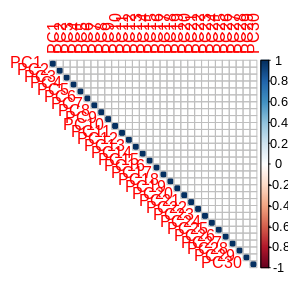

```r
# Check for colinearity between all but classe
all_cols <- names(data_train)
cor_input <- all_cols[!(all_cols %in% c("classe"))]

# Extract data frame with only predictors (all for PCA)
corvars <- data_train %>%
  select(cor_input)

corrplot(cor(corvars), type = "upper")
```

As expected, there is no colinearirity between the Pricipal Components.

# Model building

Build different models on training set and select the model that works best on validation data.

```r
# Number of cores allowed for parallel processing
parallelCoreCnt = 8

# Enable parallel
cl <- makePSOCKcluster(parallelCoreCnt)
registerDoParallel(cl)


# Data sets to include in model building
modeldatasets <- c("data_train", "data_validate")

# Function to train model and log result
trainModel <- function(methodtag, methodname, tunegrid = NULL, method = "repeatedcv", folds = 10, repeats = 10){

  trainSetting <- trainControl(method, folds, repeats, search = "grid", allowParallel = TRUE, verboseIter = TRUE)

  cat(paste("Creating model ", methodtag," with method ", method, "\n", sep = ""))
  cat(paste("Folds = ", folds, "\n", sep = ""))
  cat(paste("Repeats = ", repeats, "\n", sep = ""))


  # Save model with unique name
  modelname <- paste("model_", methodtag, sep = "")
  filename <- paste(modelname, ".RData", sep = "")
  if (file.exists(filename)) {
    # Load model from file
    cat(paste("\nLoading model from ", filename, "\n", sep = ""))
    load(filename, verbose = TRUE)
  } else {
    # Train model and save it to file
    set.seed(1)
    TrainedModel <- train(classe ~ ., method = methodtag, data = data_train, tuneGrid = tunegrid, trControl = trainSetting)
    assign(modelname, TrainedModel)
    cat(paste("\nSaving model to ", filename, "\n", sep = ""))
    save(TrainedModel, file = filename)

  }



  # Use model to predict on train and validate data, log results
  for (modeldataset in modeldatasets) {

    cat(paste("\n*** Results on ", modeldataset, ": ***\n\n", sep = ""))

    assign("modeldata", get(modeldataset))

    # Create prediction
    Prediction <- predict(TrainedModel, modeldata)

    # Print confution matrics and model performance metrics
    print(confusionMatrix(Prediction, modeldata$classe))
  }

  # Return trained model
  TrainedModel
}


#### K-Nearest Neighbors ####

methodtag <- "knn"
methodname <- "K-Nearest Neighbors"
reps <- 10

# Model specific training grid setting
tunegrid <- expand.grid(.k=c(1:4))

TrainedModel <- trainModel(methodtag, methodname, tunegrid, repeats = reps)
```

```
## Creating model knn with method repeatedcv
## Folds = 10
## Repeats = 10
##
## Loading model from model_knn.RData
## Loading objects:
##   TrainedModel
##
## *** Results on data_train: ***
##
## Confusion Matrix and Statistics
##
##           Reference
## Prediction    A    B    C    D    E
##          A 4377    0    0    0    0
##          B    0 2975    0    0    0
##          C    0    0 2682    0    0
##          D    0    0    0 2518    0
##          E    0    0    0    0 2823
##
## Overall Statistics
##
##                Accuracy : 1
##                  95% CI : (0.9998, 1)
##     No Information Rate : 0.2847
##     P-Value [Acc > NIR] : < 2.2e-16
##
##                   Kappa : 1
##
##  Mcnemar's Test P-Value : NA
##
## Statistics by Class:
##
##                      Class: A Class: B Class: C Class: D Class: E
## Sensitivity            1.0000   1.0000   1.0000   1.0000   1.0000
## Specificity            1.0000   1.0000   1.0000   1.0000   1.0000
## Pos Pred Value         1.0000   1.0000   1.0000   1.0000   1.0000
## Neg Pred Value         1.0000   1.0000   1.0000   1.0000   1.0000
## Prevalence             0.2847   0.1935   0.1744   0.1638   0.1836
## Detection Rate         0.2847   0.1935   0.1744   0.1638   0.1836
```

[output cut: 22 more lines]

```
##                   Kappa : 0.9875
##
##  Mcnemar's Test P-Value : NA
##
## Statistics by Class:
##
##                      Class: A Class: B Class: C Class: D Class: E
## Sensitivity            0.9982   0.9838   0.9851   0.9825   0.9957
## Specificity            0.9975   0.9987   0.9943   0.9978   0.9994
## Pos Pred Value         0.9936   0.9946   0.9735   0.9888   0.9972
## Neg Pred Value         0.9993   0.9961   0.9968   0.9966   0.9990
## Prevalence             0.2848   0.1934   0.1744   0.1638   0.1835
## Detection Rate         0.2843   0.1903   0.1718   0.1609   0.1828
## Detection Prevalence   0.2861   0.1914   0.1765   0.1627   0.1833
## Balanced Accuracy      0.9978   0.9913   0.9897   0.9902   0.9976
```

```r
print(TrainedModel)
```

```
## k-Nearest Neighbors
##
## 15375 samples
##    30 predictor
##     5 classes: 'A', 'B', 'C', 'D', 'E'
##
## No pre-processing
## Resampling: Cross-Validated (10 fold, repeated 10 times)
## Summary of sample sizes: 13836, 13837, 13839, 13836, 13838, 13838, ...
## Resampling results across tuning parameters:
##
##   k  Accuracy   Kappa
##   1  0.9863088  0.9826807
##   2  0.9739575  0.9670592
##   3  0.9718760  0.9644218
##   4  0.9610466  0.9507191
##
## Accuracy was used to select the optimal model using the largest value.
## The final value used for the model was k = 1.
```

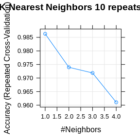

```r
plot(TrainedModel, main = paste(methodname, reps, "repeats"))
```

```r
#### Random Forests ####

methodtag <- "rf"
methodname <- "Random Forests"
folds <- 10
reps <- 5

# Model specific training grid setting
tunegrid <- expand.grid(.mtry=c(1:10))

TrainedModel <- trainModel(methodtag, methodname, tunegrid, folds = folds, repeats = reps)
```

```
## Creating model rf with method repeatedcv
## Folds = 10
## Repeats = 5
##
## Loading model from model_rf.RData
## Loading objects:
##   TrainedModel
##
## *** Results on data_train: ***
##
## Confusion Matrix and Statistics
##
##           Reference
## Prediction    A    B    C    D    E
##          A 4377    0    0    0    0
##          B    0 2975    0    0    0
##          C    0    0 2682    0    0
##          D    0    0    0 2518    0
##          E    0    0    0    0 2823
##
## Overall Statistics
##
##                Accuracy : 1
##                  95% CI : (0.9998, 1)
##     No Information Rate : 0.2847
##     P-Value [Acc > NIR] : < 2.2e-16
##
##                   Kappa : 1
##
##  Mcnemar's Test P-Value : NA
##
## Statistics by Class:
##
##                      Class: A Class: B Class: C Class: D Class: E
## Sensitivity            1.0000   1.0000   1.0000   1.0000   1.0000
## Specificity            1.0000   1.0000   1.0000   1.0000   1.0000
## Pos Pred Value         1.0000   1.0000   1.0000   1.0000   1.0000
## Neg Pred Value         1.0000   1.0000   1.0000   1.0000   1.0000
## Prevalence             0.2847   0.1935   0.1744   0.1638   0.1836
## Detection Rate         0.2847   0.1935   0.1744   0.1638   0.1836
```

[output cut: 22 more lines]

```
##                   Kappa : 0.9753
##
##  Mcnemar's Test P-Value : 0.0001393
##
## Statistics by Class:
##
##                      Class: A Class: B Class: C Class: D Class: E
## Sensitivity            0.9982   0.9758   0.9731   0.9571   0.9858
## Specificity            0.9964   0.9952   0.9868   0.9978   0.9997
## Pos Pred Value         0.9909   0.9797   0.9395   0.9885   0.9986
## Neg Pred Value         0.9993   0.9942   0.9943   0.9916   0.9968
## Prevalence             0.2848   0.1934   0.1744   0.1638   0.1835
## Detection Rate         0.2843   0.1888   0.1697   0.1567   0.1809
## Detection Prevalence   0.2869   0.1927   0.1807   0.1586   0.1812
## Balanced Accuracy      0.9973   0.9855   0.9799   0.9774   0.9927
```

```r
print(TrainedModel)
```

```
## Random Forest
##
## 15375 samples
##    30 predictor
##     5 classes: 'A', 'B', 'C', 'D', 'E'
##
## No pre-processing
## Resampling: Cross-Validated (10 fold, repeated 5 times)
## Summary of sample sizes: 13836, 13837, 13839, 13836, 13838, 13838, ...
## Resampling results across tuning parameters:
##
##   mtry  Accuracy   Kappa
##    1    0.9770795  0.9709957
##    2    0.9782501  0.9724790
##    3    0.9781593  0.9723644
##    4    0.9779251  0.9720676
##    5    0.9776519  0.9717219
##    6    0.9776518  0.9717227
##    7    0.9772484  0.9712121
##    8    0.9770272  0.9709323
##    9    0.9768583  0.9707186
##   10    0.9770925  0.9710155
##
## Accuracy was used to select the optimal model using the largest value.
## The final value used for the model was mtry = 2.
```

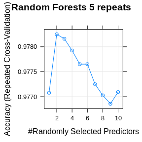

```r
plot(TrainedModel, main = paste(methodname, reps, "repeats"))
```

Of the two presented model, KNN and Random Forests, KNN clearly performs best. So I select KNN with 1 neighbor as the final model. Based on the validation set, the expected out-of-sample error is 1 - 0-9901 = 0.99%

# Predictions on test set

```r
# Load model
load("model_knn.RData")

data_test <- `pml-testing`

# Remove columns matching patterns in regpats
for (regpat in regpats) {
  data_test <- data_test[,!grepl(regpat, names(data_test))]
}

# Add features
data_test <- addfeatures(data_test)

# Normalize data
data_test[, normalize_cols] <- predict(normalize_object, data_test[, normalize_cols])

# Set data_test to PCs
data_test <- as.data.frame(predict(PCAobject, data_test))[,1:PCsIncluded]

# Predict for test test
Prediction <- predict(TrainedModel, data_test)

# Print predictions
print(Prediction)
```

```
##  [1] B A B A A E D B A A B C B A E E A B B B
## Levels: A B C D E
```